# Лабораторная работа 4-А

Кибербезопасность предприятия

Ищенко Ирина

Мишина Анастасия

Дикач Анна

Галацан Николай

Амуничников Антон

Барсегян Вардан

Дудырев Глеб

Дымченко Дмитрий

Российский университет дружбы народов, Москва, Россия

## Наша команда

- НПИбд-01-22
- Российский университет дружбы народов

## Цель тренировки

Получить доступ к флагу почтового сервера организации, расположенного на внешнем периметре.

## Способы получения флага

Флаг можно получить различными способами. Предварительно необходимо произвести разведку инфраструктуры для обнаружения и дальнейшей эксплуатации уязвимостей.

1. Разведка на предмет поиска вектора атаки
2. Использование уязвимости ProxyShell
3. Эксплуатация уязвимости ProxyLogon

# Разведка на предмет поиска вектора атаки

## Сканирование хоста на открытые порты

Просканируем подсеть просканировать подсеть 195.239.174.0/24 на открытые порты.

[figure not shown]

Поиск открытых портов

## Проверка на наличие почтового сервера

На предыдущем шаги были найдены порты, которые указывают на наличие почтового сервера. В этом можно убедиться перейдя по адресу https://195.239.174.1

[figure not shown]

Проверка на наличие почтового сервера

## Определение версии Exchange Server

С помощью режима разработчика определяем версию Server Exchange.

[figure not shown]

Определение версии Exchange Server

## CVEdetails

Для дальнейшего планирования вектора атаки будем использовать https://www.cvedetails.com.

[figure not shown]

https://www.cvedetails.com

## Список уязвимостей доступных к эксплуатации

С помощью специального фильтра получаем нужный список уязвимостей.

[figure not shown]

Список уязвимостей доступных к эксплуатации

## Детальная информация об уязвимостях

При просмотре детальной информации об уязвимостях можно убедиться, что первая дата раскрытия информации больше даты выпуска сборки атакуемого почтового сервера, значит эти уязвимости можно использовать.

## Детальная информация CVE-2021-34473

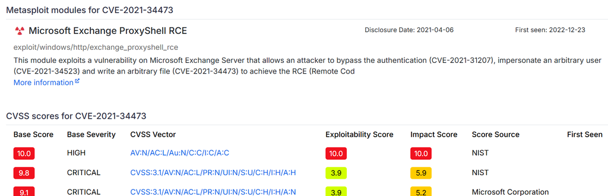

Детальная информация уязвимости CVE-2021-34473

## Детальная информация CVE-2021-26855

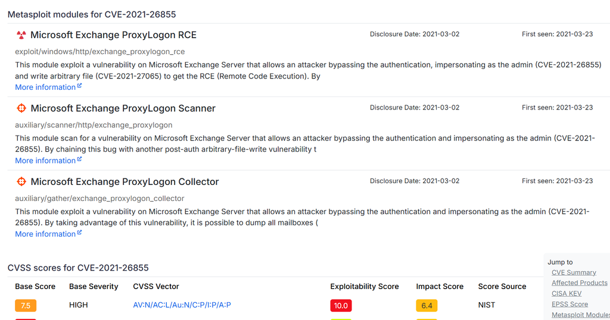

Детальная информация уязвимости CVE-2021-26855

## Сканирование с помощью Metasploit

Для поиска возможных векторов атаки будем использовать модуль Metasploit

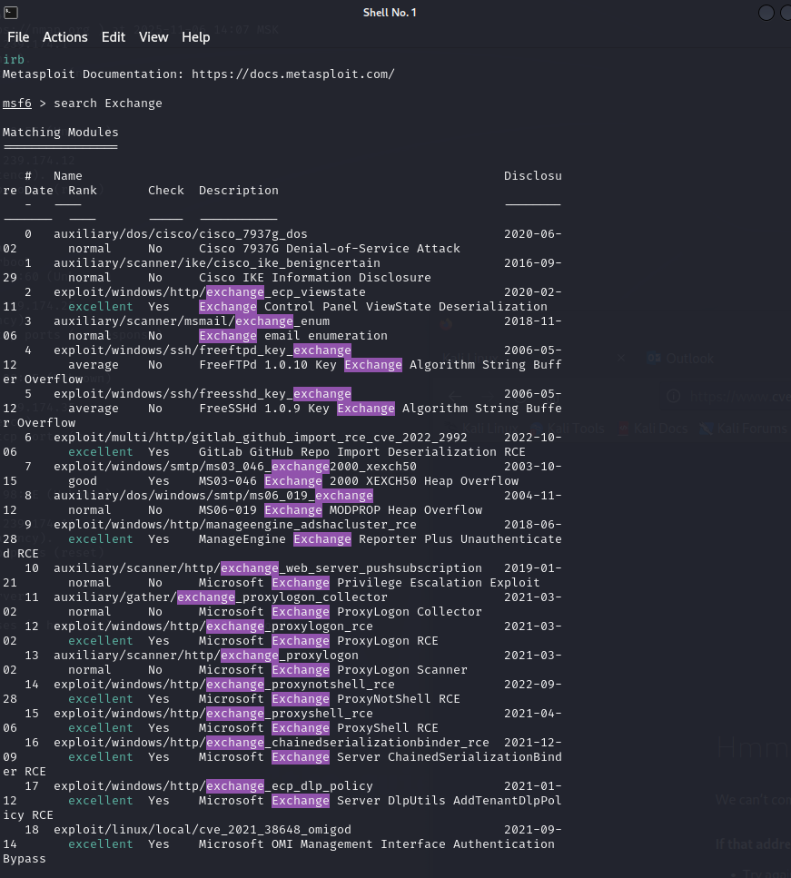

Сканирование с помощью Metasploit

# Использование уязвимости ProxyShell

## Запуск эксплуатации ProxyShell

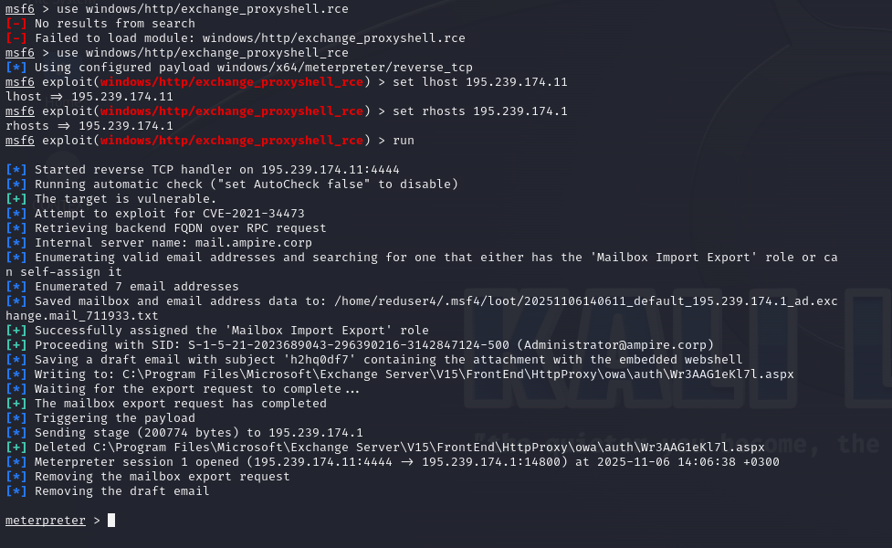

Запуск эксплуатации ProxyShell

## Получение флага

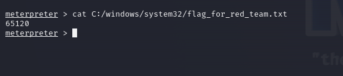

Получение флага

# Эксплуатация уязвимости ProxyLogon

## Получение соединения с удаленным узлом

С использованием почты manager1@ampire.corp можно применить данный модуль для получения соединения с удаленным узлом

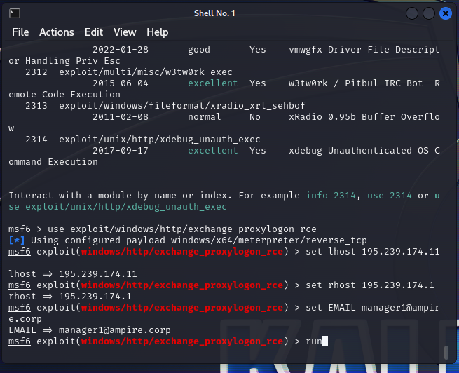

Получение соединения с удаленным узлом

## Запуск эксплуатации ProxyLogon

Следующим шагом необходимо запустить эксплуатацию ProxyLogon.

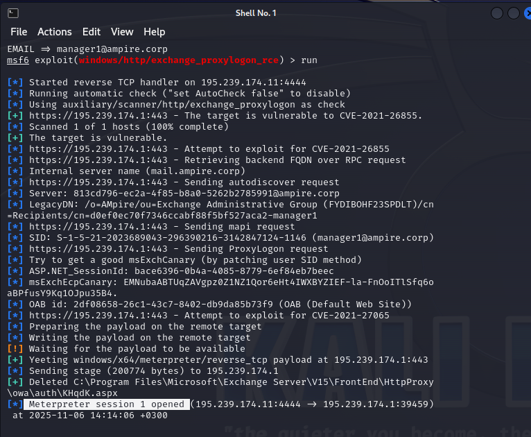

Запуск эксплуатации ProxyLogon

## Получения флага

После получения сессии с почтовым сервером можно найти флаг по пути в файле flag_for_red_team.txt

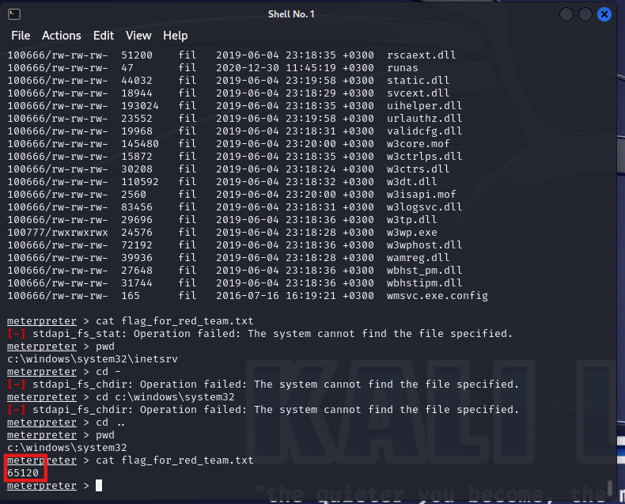

Получение флага

## Итоги

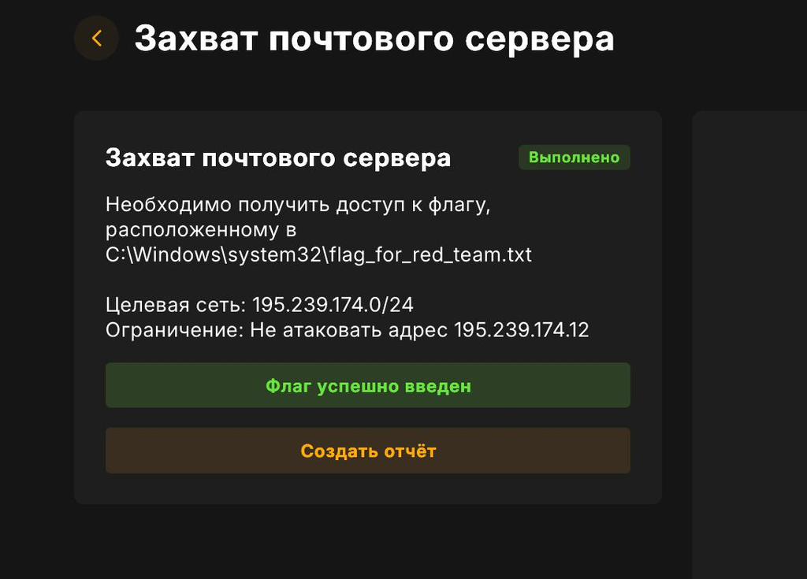

Результат

## Итоги

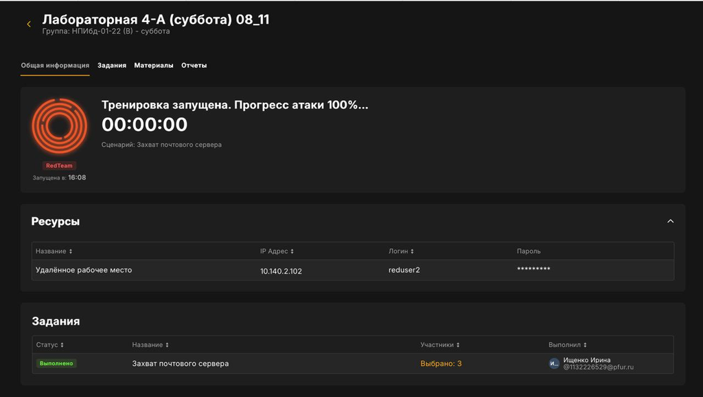

Результат